# NYC Schools Perceptions

Mykola Zotko

In this project we will work with data sets from the [New York City Department of Education](https://www.schools.nyc.gov/). They contain data on NYC schools, including student demographics, test scores, graduation and dropout rates, and school locations. We will incorporate some additional data from responses to surveys designed to gauge parent, student, and teacher perceptions of the quality of New York City schools.

```r
library(dplyr)
library(readr)
library(ggplot2)
library(purrr)
library(tidyr)
library(stringr)
```

Read preproceseed NYC schools data, [servey data](https://data.cityofnewyork.us/Education/2011-NYC-School-Survey/mnz3-dyi8) for all community schools and for all District 75 schools.

```r
combined <-  read_csv('data/combined.csv')
survey <-  read_tsv('data/masterfile11_gened_final.txt')
survey_d75 <- read_tsv('data/masterfile11_d75_final.txt')
```

Filter `survey` data to include only high schools and select columns needed for analysis.

```r
survey <- survey %>%
  filter(schooltype == "High School") %>%
  select(dbn, rr_s:aca_tot_11)
```

Select columns needed for analysis from `survey_d75`.

```r
survey_d75 <- survey_d75 %>%
  subset(is.na(highschool)) %>%
  select(dbn, rr_s:aca_tot_11)
```

Combine `survey` and `survey_d75` data frames.

```r
survey_total <- rbind(survey, survey_d75)
```

Rename `survey_total` variable `dbn` to `DBN` so can use as key to join with the `combined` data frame. Join the `combined` and `survey_total` data frames. Use `left_join()` to keep only survey data that correspond to schools for which we have data in `combined`.

```r
survey_total <- survey_total %>%
  rename(DBN = dbn)

combined_survey <- combined %>%
  left_join(survey_total, by = "DBN")

combined_survey <- combined_survey %>%
  rename(num_of_sat_takers = `Num of SAT Test Takers`,
         sat_math_avg_score = `SAT Math Avg. Score`,
         total_exams_taken = `Total Exams Taken`,
         sat_critical_reading_avg_score = `SAT Critical Reading Avg. Score`,
         sat_writing_avg_score = `SAT Writing Avg. Score`,
         ap_test_takers = `AP Test Takers`,
         number_of_exames_with_3_5 = `Number of Exams with scores 3 4 or 5`)
```

Create a correlation matrix to look for interesting relationships between pairs of variables in the new, combined data frame.

```r
cor_mat <- combined_survey %>%
  select_if(is.numeric) %>%
  cor(use = "pairwise.complete.obs")

cor_tib <- cor_mat %>%
  as_tibble(rownames = "variable")

sat_cors <- cor_tib %>%
  select(variable, avg_sat_score) %>%
  filter(avg_sat_score > 0.25 | avg_sat_score < 0.25)

sat_cors <- sat_cors[order(sat_cors$avg_sat_score), ]
```

Create a bar plot of correlation between avarage SAT score and other variables.

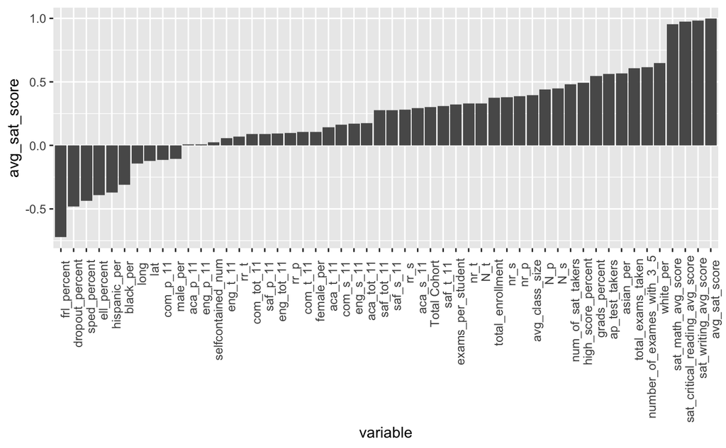

```r
sat_cors$variable <- factor(sat_cors$variable, levels = sat_cors$variable)
ggplot(data = sat_cors) +
  aes(x = variable, y = avg_sat_score) +
  theme(axis.text.x = element_text(angle = 90, hjust=0.95)) +
  geom_bar(stat = "identity")
```

Create scatter plots to explore potentially interesting relationships between variables in greater detail.

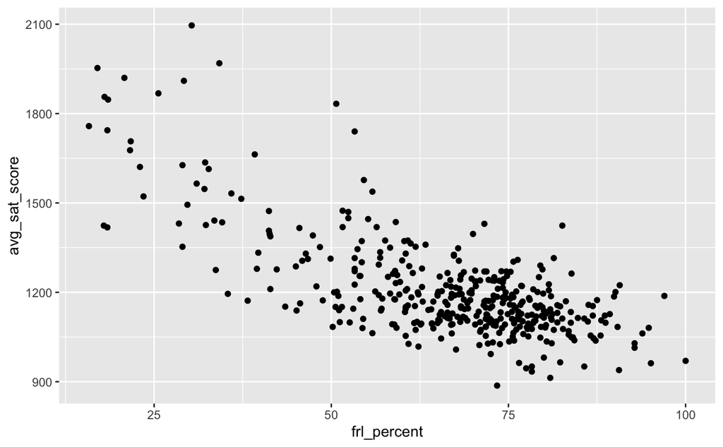

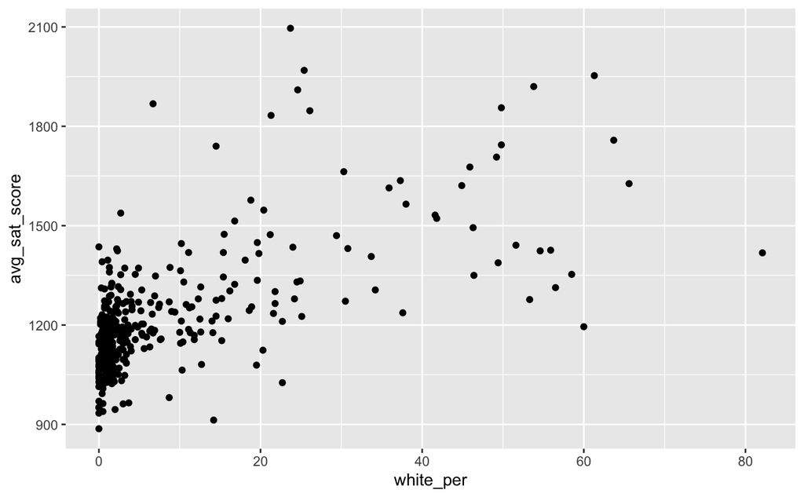

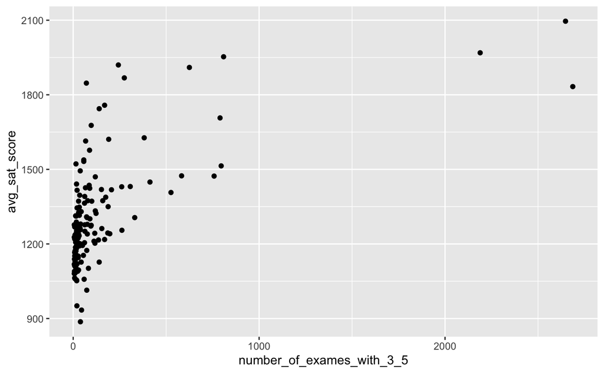

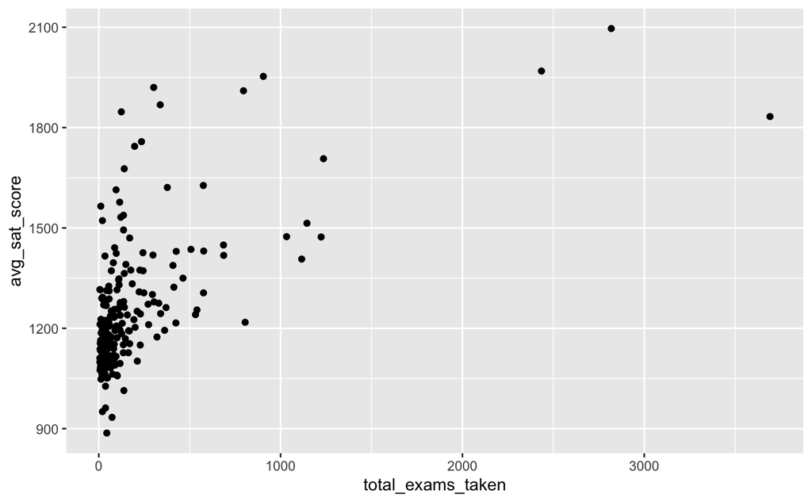

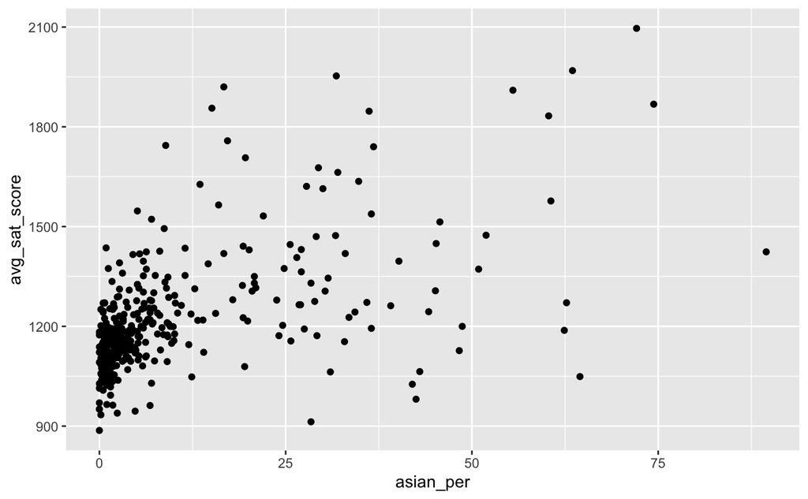

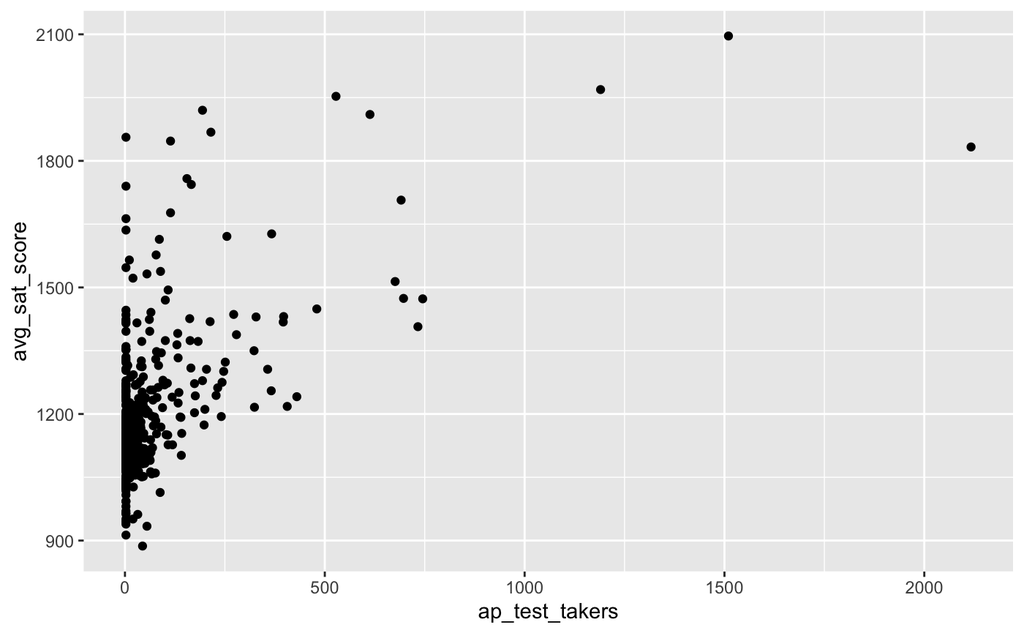

```r
ordered_cors <- sat_cors[order(-abs(sat_cors$avg_sat_score)),]
x_var = as.character(ordered_cors$variable[5:10])
y_var = "avg_sat_score"

create_scatter <- function (x, y) {
  ggplot(data = combined_survey) +
    aes_string(x = x, y = "avg_sat_score") +
    geom_point()
}

map(x_var, create_scatter)
```

Reshape the data so that we can investigate differences in student, parent, and teacher responses to survey questions.

```r
combined_gather <- combined_survey %>%
  select(DBN, school_name, saf_p_11:aca_tot_11) %>%
  gather(key='survey_question', value=score, saf_p_11:aca_tot_11)

combined_gather <- combined_gather %>%
  mutate(response_type = str_sub(combined_gather$survey_question, 4, 6),
         question = str_sub(combined_gather$survey_question, end = 3))

combined_gather <- combined_gather %>%
  mutate(response_type = ifelse(response_type == '_p_', 'parent',
                                ifelse(response_type == '_t_', 'teacher',
                                       ifelse(response_type == '_s_', 'student',
                                              ifelse(response_type == '_to', 'total', 'NA')))))
```

Make a boxplot to see if there appear to be differences in how the three groups of responders (parents, students, and teachers) answered the four questions.

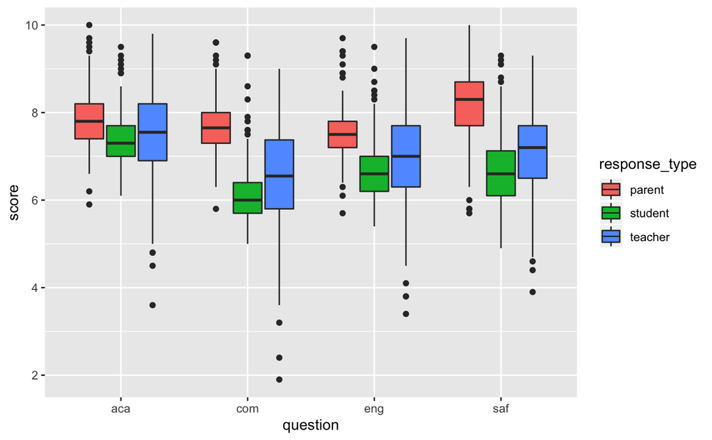

```r
combined_gather %>%
  filter(response_type != 'total') %>%
  ggplot() +
  aes(x = question, y = score, fill=response_type) +
  geom_boxplot()
```